# CAPITAL PUNISHMENT

Holden Katin-Bayer!

November 24th, 2026

# Introduction

Is attitude toward capitol punishment (cappun) independent of race (race)? If not, then whose view differs from whom??

Data in the GSS dataset provides the mydata. It originates from the University of Chicago.

$H_A$ Race correlates to attitude toward capital punishment.

$H_0$ There is no correlation between attitude and race.

# Methods

cappun is categorical.

race is categorical.

# Results

## Descriptive Results

### Graphical Descriptive Results

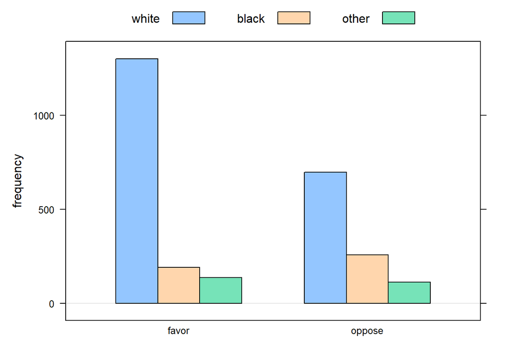

```r
barchartGC(~cappun + race,data=mydata)
```

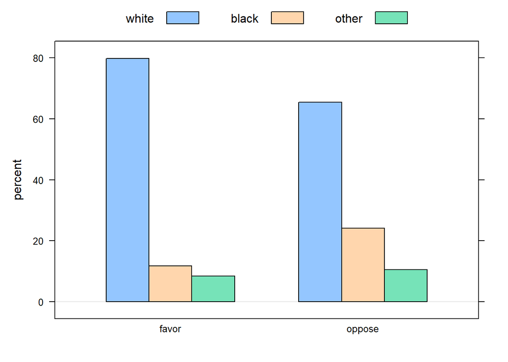

```r
barchartGC(~cappun + race,data=mydata, type="percent")
```

Races are Black, White, and Other.

The barchart suggests that the three races do not match in their opinion of capital punishment. From the data, it appears that White favors capital punishment at a higher rate than they oppose. It appears that Black opposes at a higher rate than they favor. It appears that Other favors at a higher rate than they oppose.

## Now with The Most data (fewer variables gives more data points)

### Numerical Descriptive Results

```r
table1 <- xtabs(~cappun + race, data=mydata)
rowPerc(table1)
```

```
##         race
## cappun    white  black  other  Total
##   favor   79.80  11.72   8.47 100.00
##   oppose  65.38  24.11  10.51 100.00
```

```r
colPerc(table1)
```

```
##         race
## cappun   white  black other
##   favor   65.1  42.63  55.2
##   oppose  34.9  57.37  44.8
##   Total  100.0 100.00 100.0
```

## Inferential Results

```r
fisherXY(mydata$cappun,mydata$race)
```

```
##
## contingency table:
##         y
## x        white black other
##   favor   1300   191   138
##   oppose   697   257   112
##
## ***All 2X2 tests****
##
## [1] "favor"  "oppose"
## [1] "white" "black"
##         y
## x        white black
##   favor   1300   191
##   oppose   697   257
##
##  Fisher's Exact Test for Count Data
##
## data:  fTempTable
## p-value < 2.2e-16
## alternative hypothesis: true odds ratio is not equal to 1
## 95 percent confidence interval:
##  2.026182 3.110228
## sample estimates:
## odds ratio
##   2.508637
##
##
## [1] "favor"  "oppose"
## [1] "white" "other"
##         y
## x        white other
##   favor   1300   138
##   oppose   697   112
##
##  Fisher's Exact Test for Count Data
##
## data:  fTempTable
## p-value = 0.002607
## alternative hypothesis: true odds ratio is not equal to 1
```

[output cut: 9 more lines]

```
##         y
## x        black other
##   favor    191   138
##   oppose   257   112
##
##  Fisher's Exact Test for Count Data
##
## data:  fTempTable
## p-value = 0.001564
## alternative hypothesis: true odds ratio is not equal to 1
## 95 percent confidence interval:
##  0.4362024 0.8338638
## sample estimates:
## odds ratio
##  0.6036291
```

Using the fisherxy test, we can see that all the sample races have a different view towards capital punishment. Each one has a P value less than 0.05. In addition, they each posess different odds ratios. We must reject the null hypothesis.

# Discussion and Conclusion

To repeat the initial question, we, the master RStudio statisticians of this class, are trying to find out if the view toward capital punishment is independent of race.

We reject the null hypothesis becase the P value is 0.002607 and 0.001564. This is less than 0.05.

We determine that White and Other will generally favor capital punishment, with Black deviating by generally opposing capital punishment.